# Tutorial22-DescribingData

```python
#importing the usual libraries and modules
import matplotlib.pyplot as plt
import numpy as np
```

## 2 think+type: load a simulated dataset

```python
data = np.load('noisy_sunearth.npy', allow_pickle=True) # Loading the data into am array



times, masses, positions, velocities = data # Unpack the data

#making sure the data is a numpy array
for i in range(30):
    print(f"\n index = {i} time = {times[i]} \t deltatime = {np.diff(times)[i]}")
print(f" \n \n the length of times is, {len(times)}")
```

```
 index = 0 time = 0.0 	 deltatime = 8640.0

 index = 1 time = 8640.0 	 deltatime = 8640.0

 index = 2 time = 17280.0 	 deltatime = 8640.0

 index = 3 time = 25920.0 	 deltatime = 8640.0

 index = 4 time = 34560.0 	 deltatime = 8640.0

 index = 5 time = 43200.0 	 deltatime = 8640.0

 index = 6 time = 51840.0 	 deltatime = 8640.0

 index = 7 time = 60480.0 	 deltatime = 8640.0

 index = 8 time = 69120.0 	 deltatime = 8640.0

 index = 9 time = 77760.0 	 deltatime = 8640.0

 index = 10 time = 86400.0 	 deltatime = 8640.0

 index = 11 time = 95040.0 	 deltatime = 8640.0

 index = 12 time = 103680.0 	 deltatime = 8640.0

 index = 13 time = 112320.0 	 deltatime = 8640.0

 index = 14 time = 120960.0 	 deltatime = 8640.0

 index = 15 time = 129600.0 	 deltatime = 8640.0

 index = 16 time = 138240.0 	 deltatime = 8640.0

 index = 17 time = 146880.0 	 deltatime = 8640.0

 index = 18 time = 155520.0 	 deltatime = 8640.0

 index = 19 time = 164160.0 	 deltatime = 8640.0

 index = 20 time = 172800.0 	 deltatime = 8640.0

 index = 21 time = 181440.0 	 deltatime = 8640.0

 index = 22 time = 190080.0 	 deltatime = 8640.0

 index = 23 time = 198720.0 	 deltatime = 8640.0

 index = 24 time = 207360.0 	 deltatime = 8640.0

 index = 25 time = 216000.0 	 deltatime = 8640.0

 index = 26 time = 224640.0 	 deltatime = 8640.0

 index = 27 time = 233280.0 	 deltatime = 8640.0

 index = 28 time = 241920.0 	 deltatime = 8640.0

 index = 29 time = 250560.0 	 deltatime = 8640.0


 the length of times is, 10000
```

Ok, so the times array looks to be a numpy array with 10000 data elements that start at zero and increase by 8640

```python
positions.shape
```

```
(2, 3, 10000)
```

I am a little confused by the shape of the positions array, so I will run I few lines of code to test out exactly what the shape of the positions array is

```python
print(positions[0]) #printing the first position of the positions array by indexing the most external list
print(len(positions))
print(len(positions[0]))
print(len(positions[0][0]))
```

```
[[-2.06429356e+09  6.88121671e+09  1.04649029e+10 ... -7.81924917e+09
  -7.19207306e+09  3.65289897e+10]
 [ 5.02731723e+09 -2.12069849e+10 -4.55806408e+10 ...  8.95651260e+09
   2.83084515e+10 -1.59514509e+10]
 [ 6.34281253e+09 -1.26195893e+10  3.92442919e+09 ...  6.78568100e+09
  -4.69095428e+10 -8.20254161e+09]]
2
3
10000
```

Ok, so positions seems to be a numpy array containing two numpy arrays inside it. Each internal numpy array in postions contains three more numpy arrays each of which has a length of 10000. I believe that this means positions holds the positions of two particles. Each particle is given an x, y, z position for every time step from 0 to 9999

```python
t = times/(24*60*60) # conmverting the times dimension from seconds to days
x_Earth = positions[1, 0, :] # I guess this mean Earth is the second particle in the position list so this will store all of the Earth's x positions the 0th element in the2nd dimension for all of time from 0 to 100000 seconds
```

```python
print(len(t) == len(times)) #making sure every time is still in t
```

```
True
```

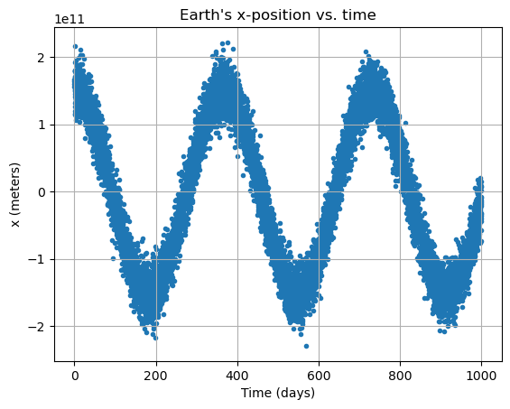

```python
#plotting Earth's x-position as a function of time
plt.scatter(t, x_Earth, marker=".")
plt.ylabel('x (meters)')
plt.xlabel('Time (days)')
plt.grid()
plt.title("Earth's x-position vs. time")
```

HAHA YES!!! The graph actually looks correct! Since Earth's orbit around the sun is pretty close to circular, with an eccentricity of 0.0167( [Earth Fact Sheet](https://nssdc.gsfc.nasa.gov/planetary/factsheet/earthfact.html)), Earth's x position should oscillate sinusoidally with a period of about 365 days.

## 3 think+write: organizing data

#### What does positions[1, 0, :] mean?

positions[1, 0, :] gives me an array containing all of the x-positions of Earth because it indexes the outer array to index position 1, which is the second element, which I am guessing is Earth. It then indexes the inner array as 0, which would refer tpp the x-position as this dimension has a length of 3 which corresponds to x,y,z, so the first element (index positions 0) would correspond to x. Then, then, : means all of the elements in the array, which refers to the innermost array, which is the time array. This means that positions[1, 0, :] would produce an array of the 2nd indexed element in the outermost array (Earth), and the first element in the inner list(x-position) and all of the elements of the innermost list (time)

#### Sun’s full (x,y,z) coordinates at the 0th time point

assuming the sun is the zeroth element in the outer list, positions[0, :, 0] would give the sun's full (x,y,z) position at the zeroth time

#### Sun and Earth's y-coordinate at all times

Since we know that the first dimension of the array, positions, has a length of 2 elements and we know that both the sun and Earth are in positions, we can simply take all of the elements from the first index position for both the sun and earth and then take the second element of the second index positon for the y value and then take all of the elements from the third index position for all time. Such code would look like:

positions[:, 1, :]

## 4 think+pair+code: What is one year?

I did this by myself at home

Also, please know I do not fully understand how to calculate chi sqaured pr how to compare my answer to it. I am currently under the impression that smaller values of N are better

```python
from fittingorbits import generateModel, calculateBadness
```

```python
def generateModel(t, period):
    '''

    Generate a model for the x-position of the Earth,
    given some orbital period (in days).
    Parameters

    ----------

    t : array of time points
    period : float
    The orbital period of Earth, expressed in days.
    Returns

    -------

    model : np.array
    Modeled x positions for the Earth,
    evaluated at every time point.
    '''
    # convert the times into orbital phase
    phase = 2*np.pi*t/period
    # define the semimajor axis (1 AU, in meters)
    a = 1.496e+11
    # return a model for the x-position, given that period
    return a*np.cos(phase)
```

```python
def calculateBadness(x_data, t, period, plot=False):
    '''

    Calculate the "badness-of-fit" for some period,
    as the sum of the squares of the residuals. This is
    basically the chi-squared, but just not scaled by
    any estimate of the intrinsic uncertainties.



    ------input-----------

    x_data : numpy array of x positions (meters)
    t : numpy array of times corresponding to x_data (days)

    period : float
    The orbital period of Earth, expressed in days.
    plot : bool
    If this keyword argument is set as `plot=True`,
    create a plot that compares the data with the model.
    If this keyword argument is set as `plot=False`,
    do not create any plots.


    ------Output------------


    badness : float
    A quantitative estimate of how bad the fit is,
    calculated as the sum of squares of the differences
    between the model and the data.
    '''
    # calculate the differences between our data and our model
    d = x_data

    m = generateModel(t, period)
    # calculate the badness of the fit


    b = np.sum((d-m)**2)
    # (this b is like chi-squared, but ignoring the errors)
    # this will generate a plot, if the plot keyword is set to True

    if plot:

        # plot the data
        plt.scatter(t, d, marker=".")
        # plot the model curve
        plt.plot(t, m, color='orange', linewidth=5, alpha=0.7)
        plt.ylabel('x (meters)')
        plt.xlabel('Time (days)')
        plt.title(f'P={period:.1f} days, $\sum(data - model)^2$ = {b:.3}')
        plt.show()

    # return the badness of fit, given the input period
    return b
```

```python
#first orbital period
t = np.linspace(0, 1000, 10000)# numpy arrau of days

period = 50 #setting the period of Earth's orbit to 50 days
```

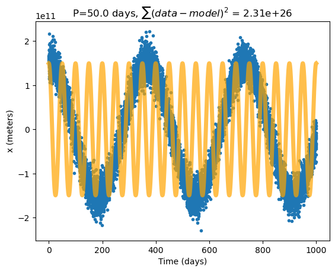

```
2.3067383768716605e+26
```

```python
calculateBadness(x_Earth, t, period, plot=True)
```

I'm dying of laughter right now as the graph looks so funny! Also, the N-squared term is extremely high so this model clearly doesn't fit.

```python
#second orbital period
#setting the period closer to try and make the model fit a little better
period = 200 #setting the period of Earth's orbit to 50 days
```

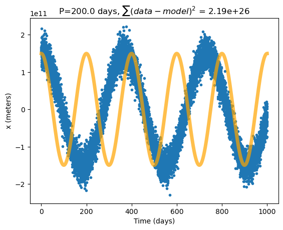

```
2.1949845133700215e+26
```

```python
calculateBadness(x_Earth, t, period, plot=True)
```

Since this value is slightly less than the value calculated on [58] I believe that means the model is improving in accuracy

```python
#third orbital period
#testing what happens if I set my period close to the correct value
period = 365 #setting the period of Earth's orbit to 365 days
```

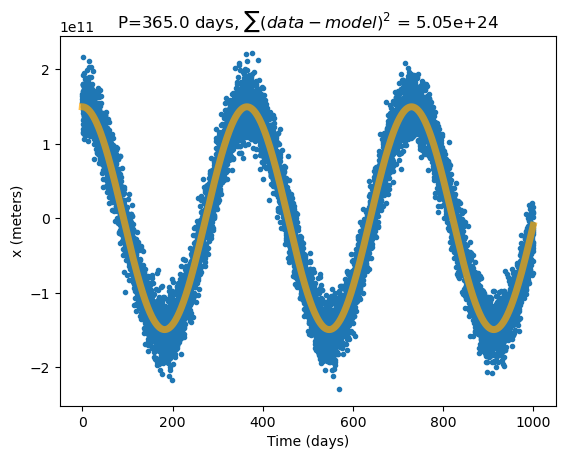

```
5.046099482804243e+24
```

```python
calculateBadness(x_Earth, t, period, plot=True)
```

Well, that has certainly improved the model's fit as the value of N calculated here is 2 orders of magnitude less than that of [60]

```python
# fourth orbital period
period = 500 #increasing the period so it's over the correct answer
```

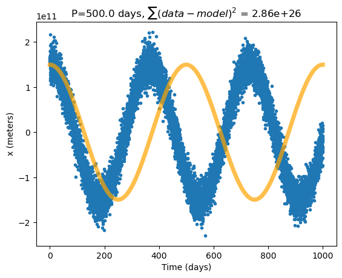

```
2.864425918628119e+26
```

```python
calculateBadness(x_Earth, t, period, plot=True)
```

Ok, so now again the N value is back to being a 26th order of magnitude number rather than a 24th order of magnitude number, such as in [67]. This makes sense as I am moving away from the correct value of period.

```python
# fifth orbital period
period = 1000 #increasing the period so it's far larger than the correct value
```

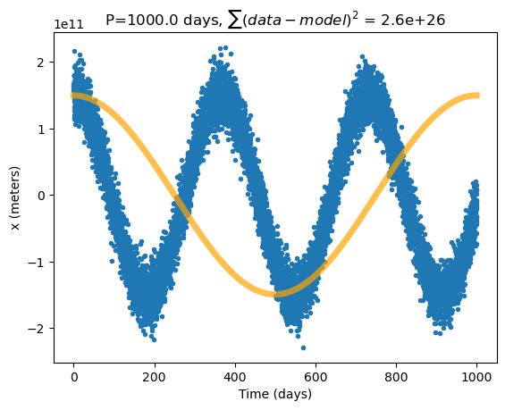

```
2.602412711199621e+26
```

```python
calculateBadness(x_Earth, t, period, plot=True)
```

```python
badness = [calculateBadness(x_Earth, t, 1, plot=False)] #creating a list to store the badness


for i in range(1, 10000): #making the for loop run 9999 times to make the total length of the list, badness 10,000
    period = 1000-i/10
    badness.append(calculateBadness(x_Earth, t, period, plot=False))

print(len(badness))#this should return 10,000
print(type(badness))
```

```
10000
<class 'list'>
```

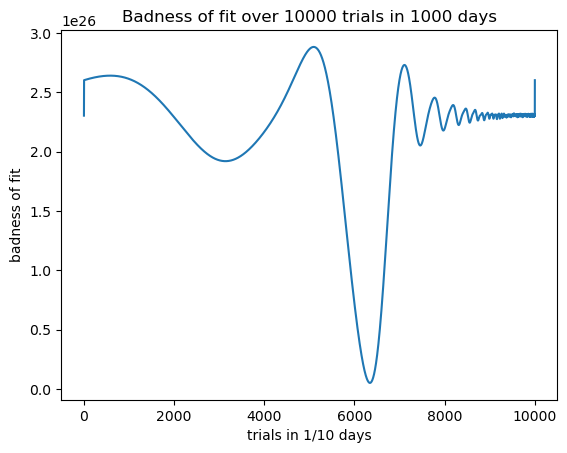

```python
x_axis = np.linspace(0,10000,10000)
badness = np.array(badness)
plt.plot(x_axis,badness)
plt.xlabel("trials in 1/10 days")
plt.ylabel("badness of fit")
plt.title("Badness of fit over 10000 trials in 1000 days")
```

```python
print(np.min(badness)) #finding the min
```

```
4.988890237848007e+24
```

```python
print(np.where(badness == 4.988890237848007e+24)) #fidning the index where badness == the min
```

```
(array([6342]),)
```

```python
print(badness[6342]) # making sure that this is where the min occours
```

```
4.988890237848007e+24
```

```python
i = -5
for i in range(-6, 7):
    print(f" at trial, {6342 + i} badness = {badness[6342 + i]}")
    i += 1
```

```
 at trial, 6336 badness = 5.014720825890658e+24
 at trial, 6337 badness = 5.006375020472712e+24
 at trial, 6338 badness = 4.999639209925793e+24
 at trial, 6339 badness = 4.99451811626152e+24
 at trial, 6340 badness = 4.991016453688585e+24
 at trial, 6341 badness = 4.989138928314925e+24
 at trial, 6342 badness = 4.988890237848007e+24
 at trial, 6343 badness = 4.990275071293152e+24
 at trial, 6344 badness = 4.993298108649953e+24
 at trial, 6345 badness = 4.997964020606757e+24
 at trial, 6346 badness = 5.004277468233257e+24
 at trial, 6347 badness = 5.012243102671204e+24
 at trial, 6348 badness = 5.021865564823209e+24
```

The badness of fit is smallest between trial 6338 and trial 6345; as that is where the minimum occurs in the curve.